# Risk Factor Analysis

## Outcome Variable

**Outcome Variable:** y_rate_haz

## Predictor Variables

**Intervention Variable:** vagbrth

**Adjustment Set:**

- arm
- sex
- W_mage
- meducyrs
- feducyrs
- hhwealth_quart
- hfoodsec
- W_mhtcm
- W_nrooms
- W_nchldlt5
- brthmon
- W_parity
- impfloor
- impsan
- safeh20
- delta_W_mage
- delta_meducyrs
- delta_feducyrs
- delta_hhwealth_quart
- delta_hfoodsec
- delta_W_mhtcm
- delta_W_nrooms
- delta_W_nchldlt5
- delta_brthmon
- delta_W_parity
- delta_impfloor
- delta_impsan
- delta_safeh20

## Stratifying Variables

The analysis was stratified on these variable(s):

- agecat
- studyid
- country

## Data Summary

| agecat | studyid | country | vagbrth | n_cell | n |
| --- | --- | --- | --- | --- | --- |
| 0-3 months | ki1000108-CMC-V-BCS-2002 | INDIA | 0 | 10 | 87 |
| 0-3 months | ki1000108-CMC-V-BCS-2002 | INDIA | 1 | 77 | 87 |
| 0-3 months | ki1000108-IRC | INDIA | 0 | 66 | 377 |
| 0-3 months | ki1000108-IRC | INDIA | 1 | 311 | 377 |
| 0-3 months | ki1017093b-PROVIDE | BANGLADESH | 0 | 148 | 634 |
| 0-3 months | ki1017093b-PROVIDE | BANGLADESH | 1 | 486 | 634 |
| 0-3 months | ki1017093c-NIH-Crypto | BANGLADESH | 0 | 193 | 469 |
| 0-3 months | ki1017093c-NIH-Crypto | BANGLADESH | 1 | 276 | 469 |
| 0-3 months | ki1119695-PROBIT | BELARUS | 0 | 1424 | 12745 |
| 0-3 months | ki1119695-PROBIT | BELARUS | 1 | 11321 | 12745 |
| 0-3 months | ki1126311-ZVITAMBO | ZIMBABWE | 0 | 683 | 7802 |
| 0-3 months | ki1126311-ZVITAMBO | ZIMBABWE | 1 | 7119 | 7802 |
| 0-3 months | kiGH5241-JiVitA-3 | BANGLADESH | 0 | 1704 | 40020 |
| 0-3 months | kiGH5241-JiVitA-3 | BANGLADESH | 1 | 38316 | 40020 |
| 0-3 months | kiGH5241-JiVitA-4 | BANGLADESH | 0 | 200 | 3610 |
| 0-3 months | kiGH5241-JiVitA-4 | BANGLADESH | 1 | 3410 | 3610 |
| 3-6 months | ki1000108-CMC-V-BCS-2002 | INDIA | 0 | 21 | 307 |
| 3-6 months | ki1000108-CMC-V-BCS-2002 | INDIA | 1 | 286 | 307 |
| 3-6 months | ki1000108-IRC | INDIA | 0 | 67 | 397 |
| 3-6 months | ki1000108-IRC | INDIA | 1 | 330 | 397 |
| 3-6 months | ki1017093b-PROVIDE | BANGLADESH | 0 | 133 | 574 |
| 3-6 months | ki1017093b-PROVIDE | BANGLADESH | 1 | 441 | 574 |
| 3-6 months | ki1017093c-NIH-Crypto | BANGLADESH | 0 | 182 | 443 |
| 3-6 months | ki1017093c-NIH-Crypto | BANGLADESH | 1 | 261 | 443 |
| 3-6 months | ki1066203-TanzaniaChild2 | TANZANIA, UNITED REPUBLIC OF | 0 | 159 | 1641 |
| 3-6 months | ki1066203-TanzaniaChild2 | TANZANIA, UNITED REPUBLIC OF | 1 | 1482 | 1641 |
| 3-6 months | ki1119695-PROBIT | BELARUS | 0 | 1473 | 13309 |
| 3-6 months | ki1119695-PROBIT | BELARUS | 1 | 11836 | 13309 |
| 3-6 months | ki1126311-ZVITAMBO | ZIMBABWE | 0 | 509 | 5842 |
| 3-6 months | ki1126311-ZVITAMBO | ZIMBABWE | 1 | 5333 | 5842 |
| 3-6 months | kiGH5241-JiVitA-3 | BANGLADESH | 0 | 1538 | 25100 |
| 3-6 months | kiGH5241-JiVitA-3 | BANGLADESH | 1 | 23562 | 25100 |
| 3-6 months | kiGH5241-JiVitA-4 | BANGLADESH | 0 | 256 | 3524 |
| 3-6 months | kiGH5241-JiVitA-4 | BANGLADESH | 1 | 3268 | 3524 |
| 6-12 months | ki1000108-CMC-V-BCS-2002 | INDIA | 0 | 22 | 323 |
| 6-12 months | ki1000108-CMC-V-BCS-2002 | INDIA | 1 | 301 | 323 |
| 6-12 months | ki1000108-IRC | INDIA | 0 | 68 | 400 |
| 6-12 months | ki1000108-IRC | INDIA | 1 | 332 | 400 |
| 6-12 months | ki1017093b-PROVIDE | BANGLADESH | 0 | 121 | 545 |
| 6-12 months | ki1017093b-PROVIDE | BANGLADESH | 1 | 424 | 545 |
| 6-12 months | ki1017093c-NIH-Crypto | BANGLADESH | 0 | 176 | 420 |
| 6-12 months | ki1017093c-NIH-Crypto | BANGLADESH | 1 | 244 | 420 |
| 6-12 months | ki1066203-TanzaniaChild2 | TANZANIA, UNITED REPUBLIC OF | 0 | 102 | 1065 |
| 6-12 months | ki1066203-TanzaniaChild2 | TANZANIA, UNITED REPUBLIC OF | 1 | 963 | 1065 |
| 6-12 months | ki1119695-PROBIT | BELARUS | 0 | 1444 | 12896 |
| 6-12 months | ki1119695-PROBIT | BELARUS | 1 | 11452 | 12896 |
| 6-12 months | ki1126311-ZVITAMBO | ZIMBABWE | 0 | 369 | 4533 |
| 6-12 months | ki1126311-ZVITAMBO | ZIMBABWE | 1 | 4164 | 4533 |
| 6-12 months | kiGH5241-JiVitA-3 | BANGLADESH | 0 | 1182 | 19606 |
| 6-12 months | kiGH5241-JiVitA-3 | BANGLADESH | 1 | 18424 | 19606 |
| 6-12 months | kiGH5241-JiVitA-4 | BANGLADESH | 0 | 474 | 5610 |
| 6-12 months | kiGH5241-JiVitA-4 | BANGLADESH | 1 | 5136 | 5610 |
| 12-24 months | ki1000108-CMC-V-BCS-2002 | INDIA | 0 | 23 | 324 |
| 12-24 months | ki1000108-CMC-V-BCS-2002 | INDIA | 1 | 301 | 324 |
| 12-24 months | ki1000108-IRC | INDIA | 0 | 67 | 396 |
| 12-24 months | ki1000108-IRC | INDIA | 1 | 329 | 396 |
| 12-24 months | ki1017093b-PROVIDE | BANGLADESH | 0 | 101 | 458 |
| 12-24 months | ki1017093b-PROVIDE | BANGLADESH | 1 | 357 | 458 |
| 12-24 months | ki1017093c-NIH-Crypto | BANGLADESH | 0 | 94 | 241 |
| 12-24 months | ki1017093c-NIH-Crypto | BANGLADESH | 1 | 147 | 241 |
| 12-24 months | ki1066203-TanzaniaChild2 | TANZANIA, UNITED REPUBLIC OF | 0 | 1 | 2 |
| 12-24 months | ki1066203-TanzaniaChild2 | TANZANIA, UNITED REPUBLIC OF | 1 | 1 | 2 |
| 12-24 months | ki1119695-PROBIT | BELARUS | 0 | 298 | 2533 |
| 12-24 months | ki1119695-PROBIT | BELARUS | 1 | 2235 | 2533 |
| 12-24 months | ki1126311-ZVITAMBO | ZIMBABWE | 0 | 20 | 297 |
| 12-24 months | ki1126311-ZVITAMBO | ZIMBABWE | 1 | 277 | 297 |
| 12-24 months | kiGH5241-JiVitA-3 | BANGLADESH | 0 | 524 | 9252 |
| 12-24 months | kiGH5241-JiVitA-3 | BANGLADESH | 1 | 8728 | 9252 |
| 12-24 months | kiGH5241-JiVitA-4 | BANGLADESH | 0 | 513 | 6223 |
| 12-24 months | kiGH5241-JiVitA-4 | BANGLADESH | 1 | 5710 | 6223 |

The following strata were considered:

- agecat: 0-3 months, studyid: ki1000108-CMC-V-BCS-2002, country: INDIA
- agecat: 0-3 months, studyid: ki1000108-IRC, country: INDIA
- agecat: 0-3 months, studyid: ki1017093b-PROVIDE, country: BANGLADESH
- agecat: 0-3 months, studyid: ki1017093c-NIH-Crypto, country: BANGLADESH
- agecat: 0-3 months, studyid: ki1119695-PROBIT, country: BELARUS
- agecat: 0-3 months, studyid: ki1126311-ZVITAMBO, country: ZIMBABWE
- agecat: 0-3 months, studyid: kiGH5241-JiVitA-3, country: BANGLADESH
- agecat: 0-3 months, studyid: kiGH5241-JiVitA-4, country: BANGLADESH
- agecat: 12-24 months, studyid: ki1000108-CMC-V-BCS-2002, country: INDIA
- agecat: 12-24 months, studyid: ki1000108-IRC, country: INDIA
- agecat: 12-24 months, studyid: ki1017093b-PROVIDE, country: BANGLADESH
- agecat: 12-24 months, studyid: ki1017093c-NIH-Crypto, country: BANGLADESH
- agecat: 12-24 months, studyid: ki1066203-TanzaniaChild2, country: TANZANIA, UNITED REPUBLIC OF
- agecat: 12-24 months, studyid: ki1119695-PROBIT, country: BELARUS
- agecat: 12-24 months, studyid: ki1126311-ZVITAMBO, country: ZIMBABWE
- agecat: 12-24 months, studyid: kiGH5241-JiVitA-3, country: BANGLADESH
- agecat: 12-24 months, studyid: kiGH5241-JiVitA-4, country: BANGLADESH
- agecat: 3-6 months, studyid: ki1000108-CMC-V-BCS-2002, country: INDIA
- agecat: 3-6 months, studyid: ki1000108-IRC, country: INDIA
- agecat: 3-6 months, studyid: ki1017093b-PROVIDE, country: BANGLADESH
- agecat: 3-6 months, studyid: ki1017093c-NIH-Crypto, country: BANGLADESH
- agecat: 3-6 months, studyid: ki1066203-TanzaniaChild2, country: TANZANIA, UNITED REPUBLIC OF
- agecat: 3-6 months, studyid: ki1119695-PROBIT, country: BELARUS
- agecat: 3-6 months, studyid: ki1126311-ZVITAMBO, country: ZIMBABWE
- agecat: 3-6 months, studyid: kiGH5241-JiVitA-3, country: BANGLADESH
- agecat: 3-6 months, studyid: kiGH5241-JiVitA-4, country: BANGLADESH
- agecat: 6-12 months, studyid: ki1000108-CMC-V-BCS-2002, country: INDIA
- agecat: 6-12 months, studyid: ki1000108-IRC, country: INDIA
- agecat: 6-12 months, studyid: ki1017093b-PROVIDE, country: BANGLADESH
- agecat: 6-12 months, studyid: ki1017093c-NIH-Crypto, country: BANGLADESH
- agecat: 6-12 months, studyid: ki1066203-TanzaniaChild2, country: TANZANIA, UNITED REPUBLIC OF
- agecat: 6-12 months, studyid: ki1119695-PROBIT, country: BELARUS
- agecat: 6-12 months, studyid: ki1126311-ZVITAMBO, country: ZIMBABWE
- agecat: 6-12 months, studyid: kiGH5241-JiVitA-3, country: BANGLADESH
- agecat: 6-12 months, studyid: kiGH5241-JiVitA-4, country: BANGLADESH

### Dropped Strata

Some strata were dropped due to rare outcomes:

- agecat: 12-24 months, studyid: ki1066203-TanzaniaChild2, country: TANZANIA, UNITED REPUBLIC OF

## Methods Detail

We’re interested in the causal parameters $E[Y_a]$ for all values of $a \in \mathcal{A}$. These parameters represent the mean outcome if, possibly contrary to fact, we intervened to set all units to have $A=a$. Under the randomization and positivity assumptions, these are identified by the statistical parameters $\psi_a=E_W[E_{Y|A,W}(Y|A=a,W)]$. In addition, we’re interested in the mean of $Y$, $E[Y]$ under no intervention (the observed mean). We will estimate these parameters by using SuperLearner to fit the relevant likelihood factors – $E_{Y|A,W}(Y|A=a,W)$ and $p(A=a|W)$, and then updating our likelihood fit using a joint TMLE.

For unadjusted analyses ($W=\{\}$), initial likelihoods were estimated using Lrnr_glm to estimate the simple $E(Y|A)$ and Lrnr_mean to estimate $p(A)$. For adjusted analyses, a small library containing Lrnr_glmnet, Lrnr_xgboost, and Lrnr_mean was used.

# Results Detail

## Results Plots

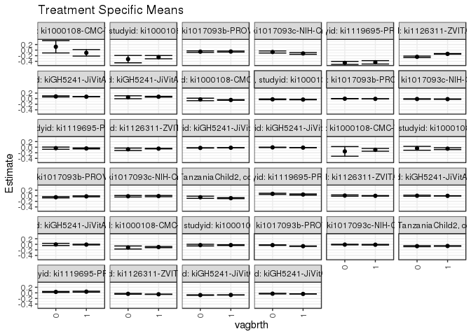

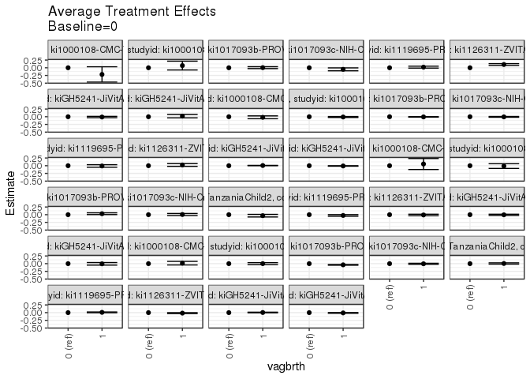

## Results Table

### Parameter: TSM

| agecat | studyid | country | intervention_level | baseline_level | estimate | ci_lower | ci_upper |
| --- | --- | --- | --- | --- | --- | --- | --- |
| 0-3 months | ki1000108-CMC-V-BCS-2002 | INDIA | 0 | NA | 0.1194888 | -0.1012668 | 0.3402444 |
| 0-3 months | ki1000108-CMC-V-BCS-2002 | INDIA | 1 | NA | -0.0976194 | -0.2137988 | 0.0185599 |
| 0-3 months | ki1000108-IRC | INDIA | 0 | NA | -0.3233356 | -0.4546268 | -0.1920444 |
| 0-3 months | ki1000108-IRC | INDIA | 1 | NA | -0.2523862 | -0.3108659 | -0.1939064 |
| 0-3 months | ki1017093b-PROVIDE | BANGLADESH | 0 | NA | -0.0553393 | -0.0826656 | -0.0280130 |
| 0-3 months | ki1017093b-PROVIDE | BANGLADESH | 1 | NA | -0.0514929 | -0.0702584 | -0.0327275 |
| 0-3 months | ki1017093c-NIH-Crypto | BANGLADESH | 0 | NA | -0.0679478 | -0.1049223 | -0.0309732 |
| 0-3 months | ki1017093c-NIH-Crypto | BANGLADESH | 1 | NA | -0.1192578 | -0.1507614 | -0.0877542 |
| 0-3 months | ki1119695-PROBIT | BELARUS | 0 | NA | -0.4573188 | -0.5107289 | -0.4039088 |
| 0-3 months | ki1119695-PROBIT | BELARUS | 1 | NA | -0.4369452 | -0.4972370 | -0.3766535 |
| 0-3 months | ki1126311-ZVITAMBO | ZIMBABWE | 0 | NA | -0.2403509 | -0.2676279 | -0.2130739 |
| 0-3 months | ki1126311-ZVITAMBO | ZIMBABWE | 1 | NA | -0.1348266 | -0.1457253 | -0.1239279 |
| 0-3 months | kiGH5241-JiVitA-3 | BANGLADESH | 0 | NA | 0.0797915 | 0.0590080 | 0.1005750 |
| 0-3 months | kiGH5241-JiVitA-3 | BANGLADESH | 1 | NA | 0.0704176 | 0.0653431 | 0.0754922 |
| 0-3 months | kiGH5241-JiVitA-4 | BANGLADESH | 0 | NA | 0.0499797 | -0.0026175 | 0.1025770 |
| 0-3 months | kiGH5241-JiVitA-4 | BANGLADESH | 1 | NA | 0.0697036 | 0.0543328 | 0.0850745 |
| 3-6 months | ki1000108-CMC-V-BCS-2002 | INDIA | 0 | NA | -0.1496943 | -0.3217145 | 0.0223260 |
| 3-6 months | ki1000108-CMC-V-BCS-2002 | INDIA | 1 | NA | -0.0941629 | -0.1436800 | -0.0446459 |
| 3-6 months | ki1000108-IRC | INDIA | 0 | NA | -0.0390748 | -0.1080555 | 0.0299059 |
| 3-6 months | ki1000108-IRC | INDIA | 1 | NA | -0.0513310 | -0.0840670 | -0.0185950 |
| 3-6 months | ki1017093b-PROVIDE | BANGLADESH | 0 | NA | -0.0527762 | -0.0755320 | -0.0300204 |
| 3-6 months | ki1017093b-PROVIDE | BANGLADESH | 1 | NA | -0.0211361 | -0.0387425 | -0.0035296 |
| 3-6 months | ki1017093c-NIH-Crypto | BANGLADESH | 0 | NA | -0.0173362 | -0.0444021 | 0.0097297 |
| 3-6 months | ki1017093c-NIH-Crypto | BANGLADESH | 1 | NA | -0.0117837 | -0.0339263 | 0.0103588 |
| 3-6 months | ki1066203-TanzaniaChild2 | TANZANIA, UNITED REPUBLIC OF | 0 | NA | -0.0532932 | -0.0921682 | -0.0144182 |
| 3-6 months | ki1066203-TanzaniaChild2 | TANZANIA, UNITED REPUBLIC OF | 1 | NA | -0.0857574 | -0.1029967 | -0.0685180 |
| 3-6 months | ki1119695-PROBIT | BELARUS | 0 | NA | 0.0694939 | 0.0477117 | 0.0912761 |
| 3-6 months | ki1119695-PROBIT | BELARUS | 1 | NA | 0.0441763 | 0.0235022 | 0.0648503 |
| 3-6 months | ki1126311-ZVITAMBO | ZIMBABWE | 0 | NA | 0.0066930 | -0.0164857 | 0.0298718 |
| 3-6 months | ki1126311-ZVITAMBO | ZIMBABWE | 1 | NA | -0.0026562 | -0.0124553 | 0.0071428 |
| 3-6 months | kiGH5241-JiVitA-3 | BANGLADESH | 0 | NA | 0.0011602 | -0.0180048 | 0.0203251 |
| 3-6 months | kiGH5241-JiVitA-3 | BANGLADESH | 1 | NA | -0.0034987 | -0.0085298 | 0.0015324 |
| 3-6 months | kiGH5241-JiVitA-4 | BANGLADESH | 0 | NA | -0.0041730 | -0.0430355 | 0.0346895 |
| 3-6 months | kiGH5241-JiVitA-4 | BANGLADESH | 1 | NA | -0.0098819 | -0.0242246 | 0.0044607 |
| 6-12 months | ki1000108-CMC-V-BCS-2002 | INDIA | 0 | NA | -0.1137676 | -0.1681992 | -0.0593360 |
| 6-12 months | ki1000108-CMC-V-BCS-2002 | INDIA | 1 | NA | -0.0980733 | -0.1195319 | -0.0766146 |
| 6-12 months | ki1000108-IRC | INDIA | 0 | NA | -0.0282145 | -0.0577263 | 0.0012974 |
| 6-12 months | ki1000108-IRC | INDIA | 1 | NA | -0.0277903 | -0.0417439 | -0.0138367 |
| 6-12 months | ki1017093b-PROVIDE | BANGLADESH | 0 | NA | -0.0281398 | -0.0378635 | -0.0184162 |
| 6-12 months | ki1017093b-PROVIDE | BANGLADESH | 1 | NA | -0.0669301 | -0.0743003 | -0.0595598 |
| 6-12 months | ki1017093c-NIH-Crypto | BANGLADESH | 0 | NA | -0.0101613 | -0.0224431 | 0.0021206 |
| 6-12 months | ki1017093c-NIH-Crypto | BANGLADESH | 1 | NA | -0.0144436 | -0.0260396 | -0.0028475 |
| 6-12 months | ki1066203-TanzaniaChild2 | TANZANIA, UNITED REPUBLIC OF | 0 | NA | -0.0659153 | -0.0848476 | -0.0469829 |
| 6-12 months | ki1066203-TanzaniaChild2 | TANZANIA, UNITED REPUBLIC OF | 1 | NA | -0.0603898 | -0.0699812 | -0.0507984 |
| 6-12 months | ki1119695-PROBIT | BELARUS | 0 | NA | 0.0338600 | 0.0178451 | 0.0498749 |
| 6-12 months | ki1119695-PROBIT | BELARUS | 1 | NA | 0.0428568 | 0.0260118 | 0.0597019 |
| 6-12 months | ki1126311-ZVITAMBO | ZIMBABWE | 0 | NA | -0.0336438 | -0.0477258 | -0.0195618 |
| 6-12 months | ki1126311-ZVITAMBO | ZIMBABWE | 1 | NA | -0.0497046 | -0.0545307 | -0.0448786 |
| 6-12 months | kiGH5241-JiVitA-3 | BANGLADESH | 0 | NA | -0.0789782 | -0.0879505 | -0.0700059 |
| 6-12 months | kiGH5241-JiVitA-3 | BANGLADESH | 1 | NA | -0.0749276 | -0.0778437 | -0.0720114 |
| 6-12 months | kiGH5241-JiVitA-4 | BANGLADESH | 0 | NA | -0.0287945 | -0.0402877 | -0.0173013 |
| 6-12 months | kiGH5241-JiVitA-4 | BANGLADESH | 1 | NA | -0.0381379 | -0.0428893 | -0.0333865 |
| 12-24 months | ki1000108-CMC-V-BCS-2002 | INDIA | 0 | NA | -0.0278590 | -0.0724343 | 0.0167164 |
| 12-24 months | ki1000108-CMC-V-BCS-2002 | INDIA | 1 | NA | -0.0468763 | -0.0572541 | -0.0364985 |
| 12-24 months | ki1000108-IRC | INDIA | 0 | NA | -0.0238797 | -0.0371945 | -0.0105650 |
| 12-24 months | ki1000108-IRC | INDIA | 1 | NA | -0.0321084 | -0.0397031 | -0.0245137 |
| 12-24 months | ki1017093b-PROVIDE | BANGLADESH | 0 | NA | -0.0017050 | -0.0071107 | 0.0037006 |
| 12-24 months | ki1017093b-PROVIDE | BANGLADESH | 1 | NA | -0.0070974 | -0.0111457 | -0.0030490 |
| 12-24 months | ki1017093c-NIH-Crypto | BANGLADESH | 0 | NA | -0.0121695 | -0.0223633 | -0.0019757 |
| 12-24 months | ki1017093c-NIH-Crypto | BANGLADESH | 1 | NA | -0.0167064 | -0.0234612 | -0.0099516 |
| 12-24 months | ki1119695-PROBIT | BELARUS | 0 | NA | -0.0346937 | -0.0736055 | 0.0042182 |
| 12-24 months | ki1119695-PROBIT | BELARUS | 1 | NA | -0.0435331 | -0.0614895 | -0.0255768 |
| 12-24 months | ki1126311-ZVITAMBO | ZIMBABWE | 0 | NA | -0.0743988 | -0.1178516 | -0.0309460 |
| 12-24 months | ki1126311-ZVITAMBO | ZIMBABWE | 1 | NA | -0.0505685 | -0.0599943 | -0.0411427 |
| 12-24 months | kiGH5241-JiVitA-3 | BANGLADESH | 0 | NA | -0.0253129 | -0.0298139 | -0.0208120 |
| 12-24 months | kiGH5241-JiVitA-3 | BANGLADESH | 1 | NA | -0.0190496 | -0.0209093 | -0.0171899 |
| 12-24 months | kiGH5241-JiVitA-4 | BANGLADESH | 0 | NA | -0.0063665 | -0.0132918 | 0.0005588 |
| 12-24 months | kiGH5241-JiVitA-4 | BANGLADESH | 1 | NA | -0.0145979 | -0.0167228 | -0.0124730 |

### Parameter: E(Y)

| agecat | studyid | country | intervention_level | baseline_level | estimate | ci_lower | ci_upper |
| --- | --- | --- | --- | --- | --- | --- | --- |
| 0-3 months | ki1000108-CMC-V-BCS-2002 | INDIA | NA | NA | -0.0732952 | -0.1806423 | 0.0340519 |
| 0-3 months | ki1000108-IRC | INDIA | NA | NA | -0.2594964 | -0.3154509 | -0.2035418 |
| 0-3 months | ki1017093b-PROVIDE | BANGLADESH | NA | NA | -0.0413143 | -0.0594662 | -0.0231624 |
| 0-3 months | ki1017093c-NIH-Crypto | BANGLADESH | NA | NA | -0.0982500 | -0.1228099 | -0.0736901 |
| 0-3 months | ki1119695-PROBIT | BELARUS | NA | NA | -0.4375900 | -0.4969173 | -0.3782626 |
| 0-3 months | ki1126311-ZVITAMBO | ZIMBABWE | NA | NA | -0.1438320 | -0.1542778 | -0.1333861 |
| 0-3 months | kiGH5241-JiVitA-3 | BANGLADESH | NA | NA | 0.0705665 | 0.0656128 | 0.0755202 |
| 0-3 months | kiGH5241-JiVitA-4 | BANGLADESH | NA | NA | 0.0672843 | 0.0522760 | 0.0822927 |
| 3-6 months | ki1000108-CMC-V-BCS-2002 | INDIA | NA | NA | -0.0979615 | -0.1455947 | -0.0503283 |
| 3-6 months | ki1000108-IRC | INDIA | NA | NA | -0.0518918 | -0.0819849 | -0.0217987 |
| 3-6 months | ki1017093b-PROVIDE | BANGLADESH | NA | NA | -0.0272428 | -0.0436954 | -0.0107902 |
| 3-6 months | ki1017093c-NIH-Crypto | BANGLADESH | NA | NA | -0.0114860 | -0.0302773 | 0.0073054 |
| 3-6 months | ki1066203-TanzaniaChild2 | TANZANIA, UNITED REPUBLIC OF | NA | NA | -0.0845892 | -0.1013959 | -0.0677825 |
| 3-6 months | ki1119695-PROBIT | BELARUS | NA | NA | 0.0470780 | 0.0278572 | 0.0662989 |
| 3-6 months | ki1126311-ZVITAMBO | ZIMBABWE | NA | NA | -0.0019119 | -0.0112787 | 0.0074549 |
| 3-6 months | kiGH5241-JiVitA-3 | BANGLADESH | NA | NA | -0.0034796 | -0.0083626 | 0.0014034 |
| 3-6 months | kiGH5241-JiVitA-4 | BANGLADESH | NA | NA | -0.0091589 | -0.0232046 | 0.0048867 |
| 6-12 months | ki1000108-CMC-V-BCS-2002 | INDIA | NA | NA | -0.0993395 | -0.1199006 | -0.0787784 |
| 6-12 months | ki1000108-IRC | INDIA | NA | NA | -0.0260151 | -0.0389122 | -0.0131180 |
| 6-12 months | ki1017093b-PROVIDE | BANGLADESH | NA | NA | -0.0626151 | -0.0695574 | -0.0556729 |
| 6-12 months | ki1017093c-NIH-Crypto | BANGLADESH | NA | NA | -0.0233651 | -0.0330011 | -0.0137291 |
| 6-12 months | ki1066203-TanzaniaChild2 | TANZANIA, UNITED REPUBLIC OF | NA | NA | -0.0595829 | -0.0688798 | -0.0502860 |
| 6-12 months | ki1119695-PROBIT | BELARUS | NA | NA | 0.0422873 | 0.0257506 | 0.0588239 |
| 6-12 months | ki1126311-ZVITAMBO | ZIMBABWE | NA | NA | -0.0488507 | -0.0535137 | -0.0441878 |
| 6-12 months | kiGH5241-JiVitA-3 | BANGLADESH | NA | NA | -0.0748712 | -0.0777013 | -0.0720410 |
| 6-12 months | kiGH5241-JiVitA-4 | BANGLADESH | NA | NA | -0.0374351 | -0.0419740 | -0.0328961 |
| 12-24 months | ki1000108-CMC-V-BCS-2002 | INDIA | NA | NA | -0.0455184 | -0.0556929 | -0.0353439 |
| 12-24 months | ki1000108-IRC | INDIA | NA | NA | -0.0317687 | -0.0388357 | -0.0247017 |
| 12-24 months | ki1017093b-PROVIDE | BANGLADESH | NA | NA | -0.0081718 | -0.0120131 | -0.0043304 |
| 12-24 months | ki1017093c-NIH-Crypto | BANGLADESH | NA | NA | -0.0149351 | -0.0207045 | -0.0091656 |
| 12-24 months | ki1119695-PROBIT | BELARUS | NA | NA | -0.0430497 | -0.0603171 | -0.0257823 |
| 12-24 months | ki1126311-ZVITAMBO | ZIMBABWE | NA | NA | -0.0516964 | -0.0610161 | -0.0423766 |
| 12-24 months | kiGH5241-JiVitA-3 | BANGLADESH | NA | NA | -0.0188086 | -0.0206601 | -0.0169571 |
| 12-24 months | kiGH5241-JiVitA-4 | BANGLADESH | NA | NA | -0.0141711 | -0.0162327 | -0.0121095 |

### Parameter: ATE

| agecat | studyid | country | intervention_level | baseline_level | estimate | ci_lower | ci_upper |
| --- | --- | --- | --- | --- | --- | --- | --- |
| 0-3 months | ki1000108-CMC-V-BCS-2002 | INDIA | 0 | 0 | 0.0000000 | 0.0000000 | 0.0000000 |
| 0-3 months | ki1000108-CMC-V-BCS-2002 | INDIA | 1 | 0 | -0.2171082 | -0.4658805 | 0.0316641 |
| 0-3 months | ki1000108-IRC | INDIA | 0 | 0 | 0.0000000 | 0.0000000 | 0.0000000 |
| 0-3 months | ki1000108-IRC | INDIA | 1 | 0 | 0.0709494 | -0.0724482 | 0.2143470 |
| 0-3 months | ki1017093b-PROVIDE | BANGLADESH | 0 | 0 | 0.0000000 | 0.0000000 | 0.0000000 |
| 0-3 months | ki1017093b-PROVIDE | BANGLADESH | 1 | 0 | 0.0038464 | -0.0270238 | 0.0347165 |
| 0-3 months | ki1017093c-NIH-Crypto | BANGLADESH | 0 | 0 | 0.0000000 | 0.0000000 | 0.0000000 |
| 0-3 months | ki1017093c-NIH-Crypto | BANGLADESH | 1 | 0 | -0.0513100 | -0.0992514 | -0.0033686 |
| 0-3 months | ki1119695-PROBIT | BELARUS | 0 | 0 | 0.0000000 | 0.0000000 | 0.0000000 |
| 0-3 months | ki1119695-PROBIT | BELARUS | 1 | 0 | 0.0203736 | -0.0103060 | 0.0510532 |
| 0-3 months | ki1126311-ZVITAMBO | ZIMBABWE | 0 | 0 | 0.0000000 | 0.0000000 | 0.0000000 |
| 0-3 months | ki1126311-ZVITAMBO | ZIMBABWE | 1 | 0 | 0.1055243 | 0.0762593 | 0.1347893 |
| 0-3 months | kiGH5241-JiVitA-3 | BANGLADESH | 0 | 0 | 0.0000000 | 0.0000000 | 0.0000000 |
| 0-3 months | kiGH5241-JiVitA-3 | BANGLADESH | 1 | 0 | -0.0093739 | -0.0307183 | 0.0119705 |
| 0-3 months | kiGH5241-JiVitA-4 | BANGLADESH | 0 | 0 | 0.0000000 | 0.0000000 | 0.0000000 |
| 0-3 months | kiGH5241-JiVitA-4 | BANGLADESH | 1 | 0 | 0.0197239 | -0.0352077 | 0.0746555 |
| 3-6 months | ki1000108-CMC-V-BCS-2002 | INDIA | 0 | 0 | 0.0000000 | 0.0000000 | 0.0000000 |
| 3-6 months | ki1000108-CMC-V-BCS-2002 | INDIA | 1 | 0 | 0.0555313 | -0.1234727 | 0.2345353 |
| 3-6 months | ki1000108-IRC | INDIA | 0 | 0 | 0.0000000 | 0.0000000 | 0.0000000 |
| 3-6 months | ki1000108-IRC | INDIA | 1 | 0 | -0.0122562 | -0.0883408 | 0.0638284 |
| 3-6 months | ki1017093b-PROVIDE | BANGLADESH | 0 | 0 | 0.0000000 | 0.0000000 | 0.0000000 |
| 3-6 months | ki1017093b-PROVIDE | BANGLADESH | 1 | 0 | 0.0316401 | 0.0030030 | 0.0602773 |
| 3-6 months | ki1017093c-NIH-Crypto | BANGLADESH | 0 | 0 | 0.0000000 | 0.0000000 | 0.0000000 |
| 3-6 months | ki1017093c-NIH-Crypto | BANGLADESH | 1 | 0 | 0.0055525 | -0.0271436 | 0.0382485 |
| 3-6 months | ki1066203-TanzaniaChild2 | TANZANIA, UNITED REPUBLIC OF | 0 | 0 | 0.0000000 | 0.0000000 | 0.0000000 |
| 3-6 months | ki1066203-TanzaniaChild2 | TANZANIA, UNITED REPUBLIC OF | 1 | 0 | -0.0324642 | -0.0744221 | 0.0094936 |
| 3-6 months | ki1119695-PROBIT | BELARUS | 0 | 0 | 0.0000000 | 0.0000000 | 0.0000000 |
| 3-6 months | ki1119695-PROBIT | BELARUS | 1 | 0 | -0.0253176 | -0.0512602 | 0.0006250 |
| 3-6 months | ki1126311-ZVITAMBO | ZIMBABWE | 0 | 0 | 0.0000000 | 0.0000000 | 0.0000000 |
| 3-6 months | ki1126311-ZVITAMBO | ZIMBABWE | 1 | 0 | -0.0093493 | -0.0343731 | 0.0156746 |
| 3-6 months | kiGH5241-JiVitA-3 | BANGLADESH | 0 | 0 | 0.0000000 | 0.0000000 | 0.0000000 |
| 3-6 months | kiGH5241-JiVitA-3 | BANGLADESH | 1 | 0 | -0.0046589 | -0.0245285 | 0.0152107 |
| 3-6 months | kiGH5241-JiVitA-4 | BANGLADESH | 0 | 0 | 0.0000000 | 0.0000000 | 0.0000000 |
| 3-6 months | kiGH5241-JiVitA-4 | BANGLADESH | 1 | 0 | -0.0057089 | -0.0466367 | 0.0352188 |
| 6-12 months | ki1000108-CMC-V-BCS-2002 | INDIA | 0 | 0 | 0.0000000 | 0.0000000 | 0.0000000 |
| 6-12 months | ki1000108-CMC-V-BCS-2002 | INDIA | 1 | 0 | 0.0156944 | -0.0424136 | 0.0738023 |
| 6-12 months | ki1000108-IRC | INDIA | 0 | 0 | 0.0000000 | 0.0000000 | 0.0000000 |
| 6-12 months | ki1000108-IRC | INDIA | 1 | 0 | 0.0004242 | -0.0321310 | 0.0329794 |
| 6-12 months | ki1017093b-PROVIDE | BANGLADESH | 0 | 0 | 0.0000000 | 0.0000000 | 0.0000000 |
| 6-12 months | ki1017093b-PROVIDE | BANGLADESH | 1 | 0 | -0.0387902 | -0.0510009 | -0.0265795 |
| 6-12 months | ki1017093c-NIH-Crypto | BANGLADESH | 0 | 0 | 0.0000000 | 0.0000000 | 0.0000000 |
| 6-12 months | ki1017093c-NIH-Crypto | BANGLADESH | 1 | 0 | -0.0042823 | -0.0203564 | 0.0117918 |
| 6-12 months | ki1066203-TanzaniaChild2 | TANZANIA, UNITED REPUBLIC OF | 0 | 0 | 0.0000000 | 0.0000000 | 0.0000000 |
| 6-12 months | ki1066203-TanzaniaChild2 | TANZANIA, UNITED REPUBLIC OF | 1 | 0 | 0.0055254 | -0.0151977 | 0.0262485 |
| 6-12 months | ki1119695-PROBIT | BELARUS | 0 | 0 | 0.0000000 | 0.0000000 | 0.0000000 |
| 6-12 months | ki1119695-PROBIT | BELARUS | 1 | 0 | 0.0089968 | -0.0037844 | 0.0217781 |
| 6-12 months | ki1126311-ZVITAMBO | ZIMBABWE | 0 | 0 | 0.0000000 | 0.0000000 | 0.0000000 |
| 6-12 months | ki1126311-ZVITAMBO | ZIMBABWE | 1 | 0 | -0.0160608 | -0.0308797 | -0.0012420 |
| 6-12 months | kiGH5241-JiVitA-3 | BANGLADESH | 0 | 0 | 0.0000000 | 0.0000000 | 0.0000000 |
| 6-12 months | kiGH5241-JiVitA-3 | BANGLADESH | 1 | 0 | 0.0040506 | -0.0055235 | 0.0136247 |
| 6-12 months | kiGH5241-JiVitA-4 | BANGLADESH | 0 | 0 | 0.0000000 | 0.0000000 | 0.0000000 |
| 6-12 months | kiGH5241-JiVitA-4 | BANGLADESH | 1 | 0 | -0.0093434 | -0.0216563 | 0.0029696 |
| 12-24 months | ki1000108-CMC-V-BCS-2002 | INDIA | 0 | 0 | 0.0000000 | 0.0000000 | 0.0000000 |
| 12-24 months | ki1000108-CMC-V-BCS-2002 | INDIA | 1 | 0 | -0.0190173 | -0.0647589 | 0.0267243 |
| 12-24 months | ki1000108-IRC | INDIA | 0 | 0 | 0.0000000 | 0.0000000 | 0.0000000 |
| 12-24 months | ki1000108-IRC | INDIA | 1 | 0 | -0.0082287 | -0.0229066 | 0.0064493 |
| 12-24 months | ki1017093b-PROVIDE | BANGLADESH | 0 | 0 | 0.0000000 | 0.0000000 | 0.0000000 |
| 12-24 months | ki1017093b-PROVIDE | BANGLADESH | 1 | 0 | -0.0053923 | -0.0120874 | 0.0013027 |
| 12-24 months | ki1017093c-NIH-Crypto | BANGLADESH | 0 | 0 | 0.0000000 | 0.0000000 | 0.0000000 |
| 12-24 months | ki1017093c-NIH-Crypto | BANGLADESH | 1 | 0 | -0.0045369 | -0.0166979 | 0.0076241 |
| 12-24 months | ki1119695-PROBIT | BELARUS | 0 | 0 | 0.0000000 | 0.0000000 | 0.0000000 |
| 12-24 months | ki1119695-PROBIT | BELARUS | 1 | 0 | -0.0088394 | -0.0504241 | 0.0327452 |
| 12-24 months | ki1126311-ZVITAMBO | ZIMBABWE | 0 | 0 | 0.0000000 | 0.0000000 | 0.0000000 |
| 12-24 months | ki1126311-ZVITAMBO | ZIMBABWE | 1 | 0 | 0.0238303 | -0.0206356 | 0.0682962 |
| 12-24 months | kiGH5241-JiVitA-3 | BANGLADESH | 0 | 0 | 0.0000000 | 0.0000000 | 0.0000000 |
| 12-24 months | kiGH5241-JiVitA-3 | BANGLADESH | 1 | 0 | 0.0062634 | 0.0015180 | 0.0110087 |
| 12-24 months | kiGH5241-JiVitA-4 | BANGLADESH | 0 | 0 | 0.0000000 | 0.0000000 | 0.0000000 |
| 12-24 months | kiGH5241-JiVitA-4 | BANGLADESH | 1 | 0 | -0.0082314 | -0.0153820 | -0.0010808 |